# Han Nguyen's Data Project

Efficient energy management is crucial for optimizing building operations, particularly in light of increasing energy consumption. In Australia, energy use rose by 2.0% in 2022–23, reaching 5,882 petajoules, highlighting the urgent need for effective energy solutions (Department of Climate Change, Energy, The Environment and Water, 2023). This report aims to develop a predictive model for Heating Load, which quantifies the daily energy required to maintain comfortable indoor temperatures in buildings.

The variable HeatingLoad in the dataset HeatingLoad training.csv represents the daily energy required to maintain comfortable indoor temperatures in buildings. This data includes several predictors that influence heating load, such as building characteristics, environmental conditions, and occupancy. The response variable and covariates are detailed in the table below.

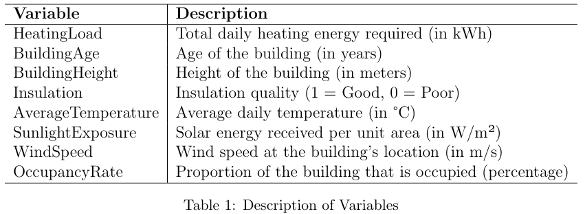

Our approach involves employing various model and variable selection techniques, such as Linear Regression, Forward and Backward Selection, K-Nearest Neighbors, Lasso, and Ridge Regression. We compare these models using metrics such as Root Mean Squared Error, Mean Squared Error, Mean Absolute Error, and Adjusted R-squared. Ultimately, our goal is to mitigate excessive energy consumption, optimize heating systems, and promote sustainable energy practices in building management. This model will enhance energy efficiency consulting efforts, facilitating more strategic and cost-effective operations of heating systems.

```python
%matplotlib inline
import pandas as pd
import numpy as np
import matplotlib.pyplot as plt

import seaborn as sns
import statsmodels.formula.api as smf

from sklearn import neighbors
```

```python
# This is to clear the warnings from the notebook, usually we should leave this on
import warnings
warnings.filterwarnings('ignore')

# Plot settings
sns.set_context('notebook') # optimises figures for notebook display
sns.set_style('ticks') # set default plot style
colours = ['#4E79A7','#F28E2C','#E15759','#76B7B2','#59A14F',
          '#EDC949','#AF7AA1','#FF9DA7','#9C755F','#BAB0AB']
sns.set_palette(colours) # set custom color scheme
%matplotlib inline
plt.rcParams['figure.figsize'] = (9, 6)
```

# 1. Exploratory data analysis (EDA)

```python
data_train = pd.read_csv('HeatingLoad_training.csv')

data_train.head()
```

|  | BuildingAge | BuildingHeight | Insulation | AverageTemperature | SunlightExposure | WindSpeed | OccupancyRate | HeatingLoad |
| --- | --- | --- | --- | --- | --- | --- | --- | --- |
| 0 | 18.56 | 30.36 | 1 | 13.75 | 453.67 | 3.89 | 0.65 | 275.89 |
| 1 | 13.82 | 9.64 | 0 | 18.70 | 138.85 | 0.95 | 0.55 | 208.02 |
| 2 | 36.47 | 8.44 | 1 | 18.23 | 190.31 | 4.71 | 0.56 | 234.86 |
| 3 | 23.23 | 18.71 | 1 | 21.89 | 313.15 | 8.51 | 0.25 | 243.89 |
| 4 | 11.62 | 11.95 | 0 | 19.49 | 117.53 | 1.57 | 0.58 | 205.94 |

- **Shuffle data:**

```python
data_train = data_train.sample(frac=1, random_state= 50)
```

```python
data_train.head()
```

|  | BuildingAge | BuildingHeight | Insulation | AverageTemperature | SunlightExposure | WindSpeed | OccupancyRate | HeatingLoad |
| --- | --- | --- | --- | --- | --- | --- | --- | --- |
| 9102 | 21.17 | 8.96 | 0 | 21.04 | 163.88 | 1.23 | 0.26 | 208.60 |
| 7868 | 15.84 | 10.09 | 1 | 17.33 | 7.00 | 5.20 | 0.74 | 218.18 |
| 4176 | 26.87 | 8.31 | 0 | 14.75 | 278.43 | 8.36 | 0.75 | 235.33 |
| 4161 | 12.59 | 5.62 | 0 | 11.43 | 270.46 | 5.53 | 0.68 | 212.29 |
| 8770 | 27.70 | 36.66 | 1 | 17.50 | 779.39 | 4.68 | 0.50 | 294.26 |

```python
data_train.shape
```

```
(10000, 8)
```

```python
data_train.info()
```

```
<class 'pandas.core.frame.DataFrame'>
Int64Index: 10000 entries, 9102 to 5600
Data columns (total 8 columns):
 #   Column              Non-Null Count  Dtype
---  ------              --------------  -----
 0   BuildingAge         10000 non-null  float64
 1   BuildingHeight      10000 non-null  float64
 2   Insulation          10000 non-null  int64
 3   AverageTemperature  10000 non-null  float64
 4   SunlightExposure    10000 non-null  float64
 5   WindSpeed           10000 non-null  float64
 6   OccupancyRate       10000 non-null  float64
 7   HeatingLoad         10000 non-null  float64
dtypes: float64(7), int64(1)
memory usage: 703.1 KB
```

```python
data_train.describe()
```

|  | BuildingAge | BuildingHeight | Insulation | AverageTemperature | SunlightExposure | WindSpeed | OccupancyRate | HeatingLoad |
| --- | --- | --- | --- | --- | --- | --- | --- | --- |
| count | 10000.000000 | 10000.000000 | 10000.000000 | 10000.000000 | 10000.000000 | 10000.000000 | 10000.000000 | 10000.000000 |
| mean | 22.765466 | 20.792105 | 0.596000 | 18.024851 | 271.361610 | 4.490681 | 0.500124 | 260.078634 |
| std | 12.385964 | 16.882672 | 0.490722 | 4.090699 | 229.275176 | 2.531248 | 0.221971 | 74.591892 |
| min | 2.990000 | 3.070000 | 0.000000 | 1.680000 | 1.150000 | 0.070000 | 0.010000 | 173.680000 |
| 25% | 14.250000 | 9.310000 | 0.000000 | 15.270000 | 100.082500 | 2.610000 | 0.330000 | 218.087500 |
| 50% | 20.090000 | 15.020000 | 1.000000 | 18.020000 | 182.435000 | 4.100000 | 0.500000 | 236.800000 |
| 75% | 28.092500 | 25.830000 | 1.000000 | 20.810000 | 407.090000 | 5.960000 | 0.670000 | 270.350000 |
| max | 153.880000 | 106.360000 | 1.000000 | 34.340000 | 1250.710000 | 18.910000 | 1.000000 | 793.920000 |

The dataset contains 10,000 observations representing 10,000 buildings and includes 8 variables: one response variable, Heating Load, and seven predictors - Building Age, Building Height, Insulation, Average Temperature, Sunlight Exposure, Wind Speed, and Occupancy Rate - used to predict Heating Load. Among the variables, 7 are numerical, while Insulation is categorical, with 0 for low-quality insulation and 1 for good-quality insulation.

```python
data_train.isnull().sum()
```

```
BuildingAge           0
BuildingHeight        0
Insulation            0
AverageTemperature    0
SunlightExposure      0
WindSpeed             0
OccupancyRate         0
HeatingLoad           0
dtype: int64
```

To mitigate order bias during model development, the dataset was shuffled using random_state=50 prior to analysis. This ensures the model learns general patterns in the data rather than memorizing any specific order of observations, contributing to more reliable and robust predictive performance (Dutta, 2024). Additionally, rather than splitting the data into training and validation sets, cross-validation will be consistently used throughout the analysis to evaluate model performance and preserve data integrity (Chanaka Prasanna, 2024).

### 1.1. Examine the Y variable Heating Load

```python
data_train[['HeatingLoad']].head()
```

|  | HeatingLoad |
| --- | --- |
| 9102 | 208.60 |
| 7868 | 218.18 |
| 4176 | 235.33 |
| 4161 | 212.29 |
| 8770 | 294.26 |

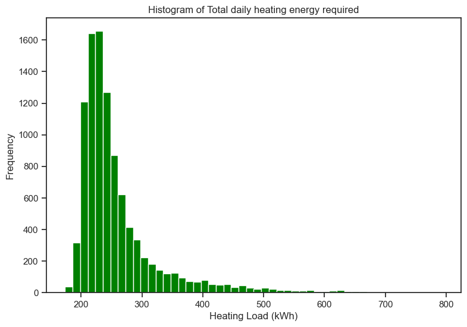

```python
plt.hist(data_train['HeatingLoad'], bins = 50, color = 'Green', alpha = 1)

plt.xlabel('Heating Load (kWh)');plt.ylabel('Frequency')
plt.title('Histogram of Total daily heating energy required')

plt.show()

plt.savefig('fig1.pdf')################## dont screenshot
```

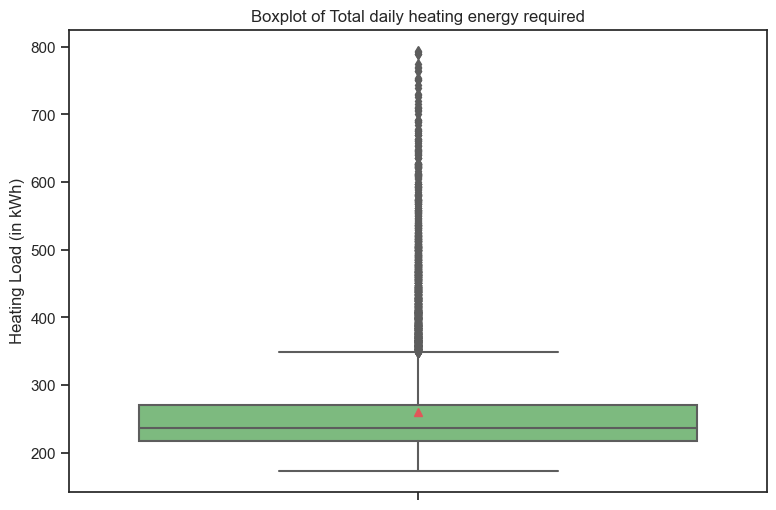

```python
heating_boxplot = sns.boxplot(y='HeatingLoad', data=data_train, palette='Greens', showmeans=True)

plt.ylabel('Heating Load (in kWh)')
plt.title('Boxplot of Total daily heating energy required')

plt.show()
```

The distribution analysis shows a right-skewed pattern, with histograms and boxplots indicating that most buildings require heating energy below 250 kWh. This skewness suggests the presence of a relatively small number of buildings that require exceptionally high energy daily, which extends the distribution's tail to the right.

### 1.2. Examine the distributions of predictors:

### 1.2.1. Numerical predictors

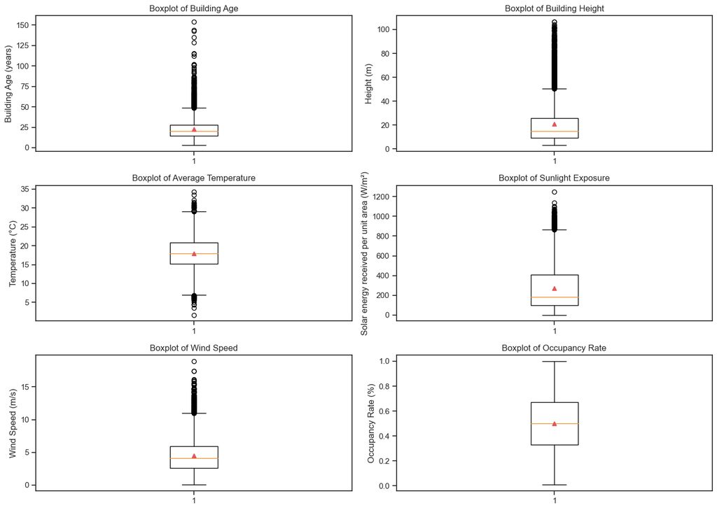

```python
fig = plt.figure(figsize=(14,10))
ax1 = fig.add_subplot(3,2,1)
ax2 = fig.add_subplot(3,2,2)
ax3 = fig.add_subplot(3,2,3)
ax4 = fig.add_subplot(3,2,4)
ax5 = fig.add_subplot(3,2,5)
ax6 = fig.add_subplot(3,2,6)

# Boxplots for each variable
ax1.boxplot(data_train['BuildingAge'], showmeans=True)
ax1.set(title='Boxplot of Building Age', ylabel='Building Age (years)')

ax2.boxplot(data_train['BuildingHeight'], showmeans=True)
ax2.set(title='Boxplot of Building Height', ylabel='Height (m)')

ax3.boxplot(data_train['AverageTemperature'], showmeans=True)
ax3.set(title='Boxplot of Average Temperature', ylabel='Temperature (°C)')

ax4.boxplot(data_train['SunlightExposure'], showmeans=True)
ax4.set(title='Boxplot of Sunlight Exposure', ylabel='Solar energy received per unit area (W/m²)')

ax5.boxplot(data_train['WindSpeed'], showmeans=True)
ax5.set(title='Boxplot of Wind Speed', ylabel='Wind Speed (m/s)')

ax6.boxplot(data_train['OccupancyRate'], showmeans=True)
ax6.set(title='Boxplot of Occupancy Rate', ylabel='Occupancy Rate (%)')

# Adjust layout for better spacing
plt.tight_layout()
plt.show()
```

### 1.2.2. Categorical predictor - Insulation

Since there is only one categorical variable—Insulation Quality—in the dataset, a brief evaluation will be conducted to examine any significant insights. The dataset contains 10,000 observations, with 5,960 buildings featuring high-quality insulation and 4,040 with low-quality insulation.

```python
print(data_train['Insulation'].value_counts())

poor_insulation = data_train[data_train['Insulation'] == 0]
good_insulation = data_train[data_train['Insulation'] == 1]
```

```
1    5960
0    4040
Name: Insulation, dtype: int64
```

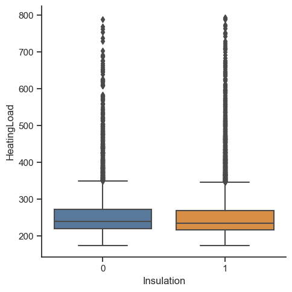

```python
sns.catplot(x="Insulation", y="HeatingLoad", kind="box", data=data_train)
plt.show()
```

```python
print('POOR INSULATION')
print('Mean heating load: ${:.2f}'.format(poor_insulation['HeatingLoad'].mean()))

print('GOOD INSULATION')
print('Mean heating load: ${:.2f}'.format(good_insulation['HeatingLoad'].mean()))
```

```
POOR INSULATION
Mean heating load: $261.91
GOOD INSULATION
Mean heating load: $258.84
```

The mean seems to be the same for the quality of insulation. However, it is impossible to gain a detailed understanding of behaviour from the simple statistics calculated above. To gain some further insight we have plotted the distribution of HeatLoad by Insulation quality.

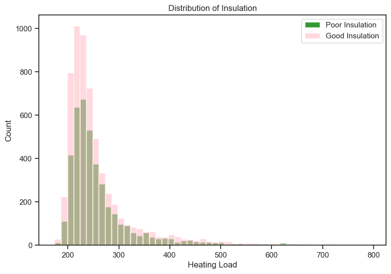

```python
plt.hist(poor_insulation['HeatingLoad'], bins = 50, color = 'green', label = 'Poor Insulation', alpha = 0.8)
plt.hist(good_insulation['HeatingLoad'], bins = 50, color = 'pink', label = 'Good Insulation', alpha = 0.6)

plt.xlabel('Heating Load'); plt.ylabel('Count'); plt.title('Distribution of Insulation')
plt.legend(); plt.show()
```

The two distributions seem to overlap each other. Therefore, no significance difference.

### 1.3. Examine relationship between HeatingLoad and other predictors

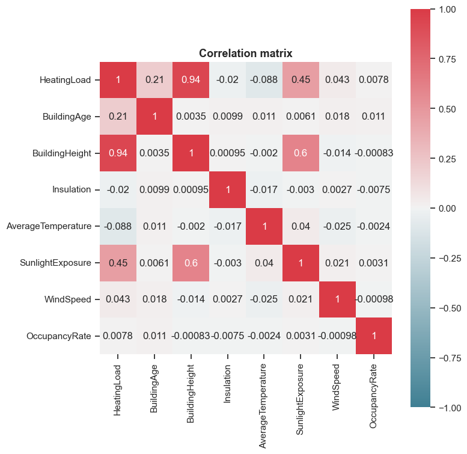

```python
fig, ax = plt.subplots(figsize = (8,8))
variables=['HeatingLoad','BuildingAge','BuildingHeight','Insulation','AverageTemperature','SunlightExposure','WindSpeed','OccupancyRate']
cmap = sns.diverging_palette(220, 10, as_cmap=True) #color map
sns.heatmap(data_train[variables].corr(), vmax=1, vmin=-1, center=0, square=True, ax=ax, cmap=cmap, annot=True)
ax.set_title('Correlation matrix', fontweight='bold', fontsize=13)
plt.tight_layout()
```

```python
data_train[variables].corr().round(2)
```

|  | HeatingLoad | BuildingAge | BuildingHeight | Insulation | AverageTemperature | SunlightExposure | WindSpeed | OccupancyRate |
| --- | --- | --- | --- | --- | --- | --- | --- | --- |
| HeatingLoad | 1.00 | 0.21 | 0.94 | -0.02 | -0.09 | 0.45 | 0.04 | 0.01 |
| BuildingAge | 0.21 | 1.00 | 0.00 | 0.01 | 0.01 | 0.01 | 0.02 | 0.01 |
| BuildingHeight | 0.94 | 0.00 | 1.00 | 0.00 | -0.00 | 0.60 | -0.01 | -0.00 |
| Insulation | -0.02 | 0.01 | 0.00 | 1.00 | -0.02 | -0.00 | 0.00 | -0.01 |
| AverageTemperature | -0.09 | 0.01 | -0.00 | -0.02 | 1.00 | 0.04 | -0.03 | -0.00 |
| SunlightExposure | 0.45 | 0.01 | 0.60 | -0.00 | 0.04 | 1.00 | 0.02 | 0.00 |
| WindSpeed | 0.04 | 0.02 | -0.01 | 0.00 | -0.03 | 0.02 | 1.00 | -0.00 |
| OccupancyRate | 0.01 | 0.01 | -0.00 | -0.01 | -0.00 | 0.00 | -0.00 | 1.00 |

The heatmap analysis reveals that the predictors most strongly correlated with Heating Load are Building Height (0.94), Sunlight Exposure (0.45), and Building Age (0.21), while the remaining predictors show low correlation. Most variables exhibit a positive correlation with Heating Load, except for Insulation and Average Temperature, which have a weak negative correlation.

Additionally, Building Height and Sunlight Exposure are highly correlated (0.6), raising potential collinearity concerns when included in the same regression model. Therefore, it is advisable to further examine this relationship using a more precise method, such as the Variance Inflation Factor (VIF).

- **Pairplot:**

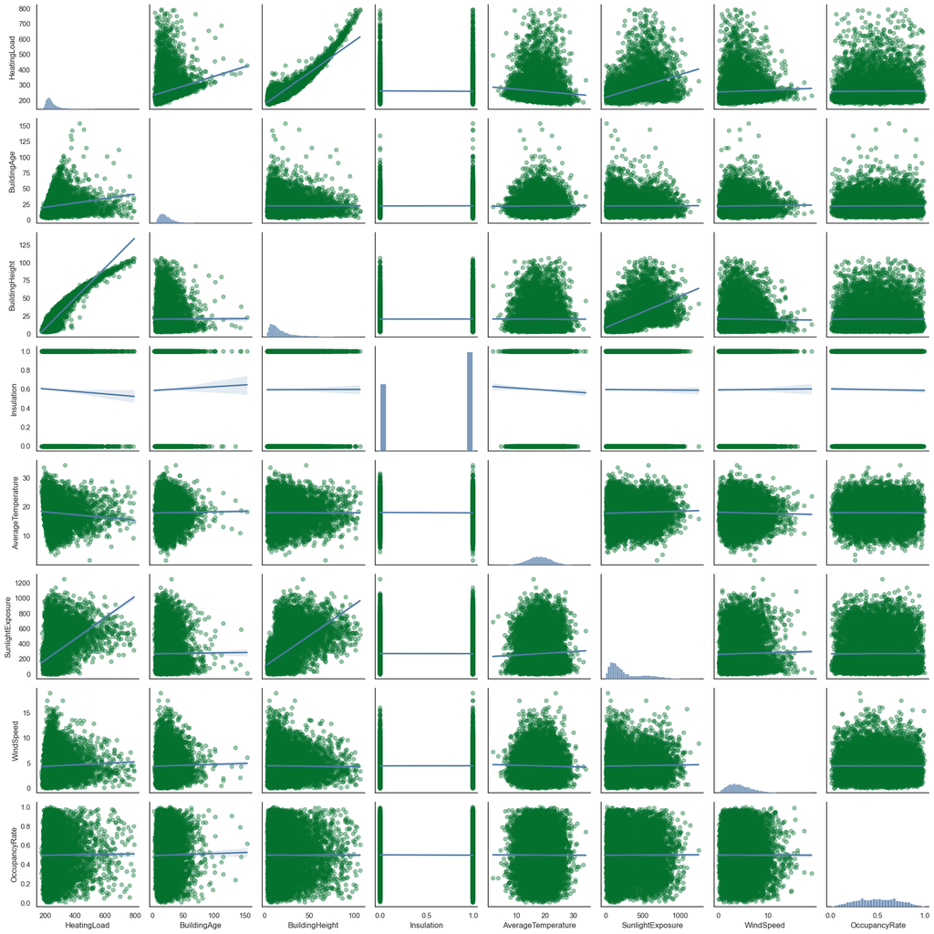

```python
with sns.axes_style('white'):
    g=sns.pairplot(data_train[variables], kind='reg',
                    plot_kws={'scatter_kws' :{'color': sns.color_palette('Greens')[-1], 'alpha': 0.4}})
plt.tight_layout()

plt.savefig(fname='Pairplot2820')
```

### 1.3.1. Between BuidlingHeight and Heating Load

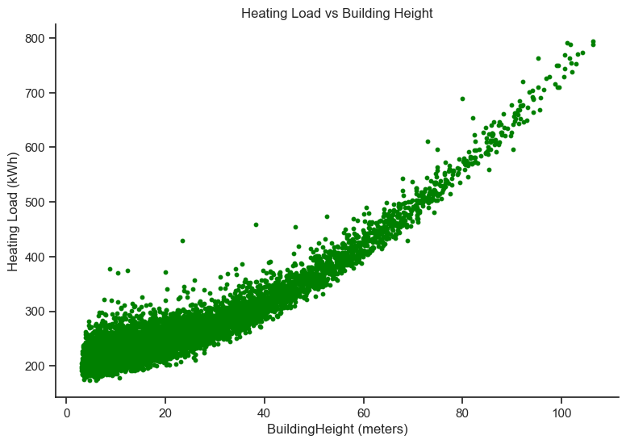

```python
fig, ax = plt.subplots() #creating an empty figure
plt.scatter(data_train['BuildingHeight'], data_train['HeatingLoad'], s=10, color='Green', alpha=1)
#Setting lables
ax.set_xlabel('BuildingHeight (meters)')
ax.set_ylabel('Heating Load (kWh)')
plt.title('Heating Load vs Building Height')
sns.despine() #Removing the spine around the plot
plt.show()
```

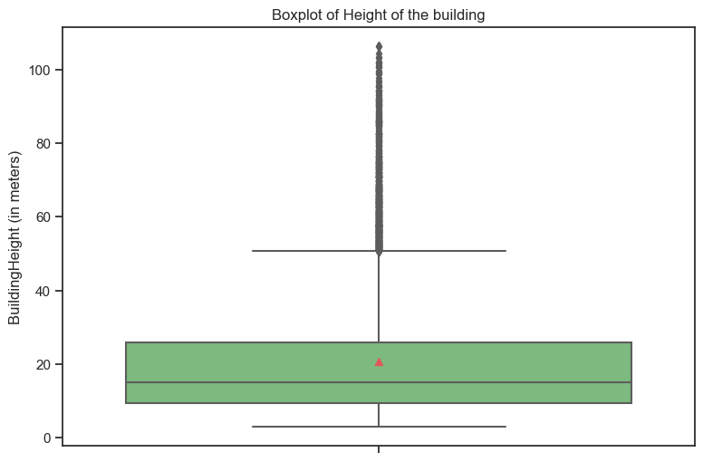

```python
buidheight_boxplot = sns.boxplot(y='BuildingHeight', data=data_train, palette='Greens', showmeans=True)

plt.ylabel('BuildingHeight (in meters)')
plt.title('Boxplot of Height of the building')

plt.show()
```

## 1.4. Examine predictors in the test dataset

```python
data_test = pd.read_csv('HeatingLoad_test_without_HL.csv')

data_test.head()
```

|  | BuildingAge | BuildingHeight | Insulation | AverageTemperature | SunlightExposure | WindSpeed | OccupancyRate |
| --- | --- | --- | --- | --- | --- | --- | --- |
| 0 | 28.15 | 9.74 | 0 | 14.97 | 359.43 | 3.53 | 0.42 |
| 1 | 20.36 | 8.40 | 1 | 24.49 | 16.08 | 3.05 | 0.73 |
| 2 | 9.84 | 43.98 | 0 | 18.05 | 406.94 | 3.61 | 0.42 |
| 3 | 22.90 | 16.08 | 0 | 13.25 | 204.26 | 0.87 | 0.76 |
| 4 | 7.35 | 9.83 | 0 | 20.77 | 285.73 | 3.11 | 0.14 |

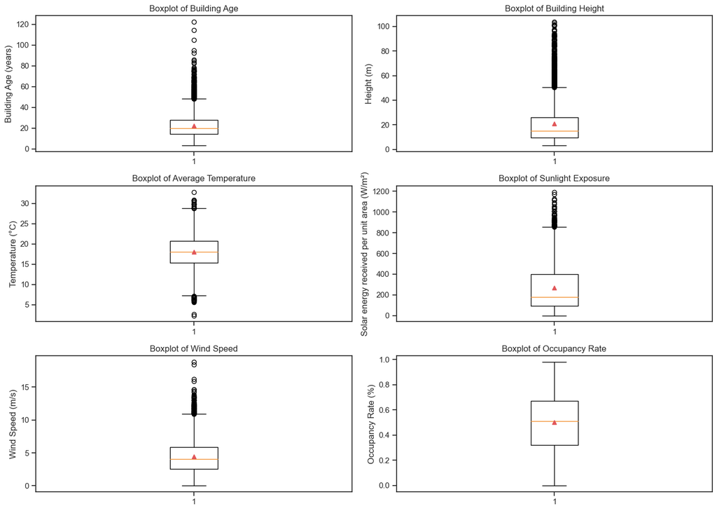

```python
fig = plt.figure(figsize=(14,10))
ax1 = fig.add_subplot(3,2,1)
ax2 = fig.add_subplot(3,2,2)
ax3 = fig.add_subplot(3,2,3)
ax4 = fig.add_subplot(3,2,4)
ax5 = fig.add_subplot(3,2,5)
ax6 = fig.add_subplot(3,2,6)

# Boxplots for each variable
ax1.boxplot(data_test['BuildingAge'], showmeans=True)
ax1.set(title='Boxplot of Building Age', ylabel='Building Age (years)')

ax2.boxplot(data_test['BuildingHeight'], showmeans=True)
ax2.set(title='Boxplot of Building Height', ylabel='Height (m)')

ax3.boxplot(data_test['AverageTemperature'], showmeans=True)
ax3.set(title='Boxplot of Average Temperature', ylabel='Temperature (°C)')

ax4.boxplot(data_test['SunlightExposure'], showmeans=True)
ax4.set(title='Boxplot of Sunlight Exposure', ylabel='Solar energy received per unit area (W/m²)')

ax5.boxplot(data_test['WindSpeed'], showmeans=True)
ax5.set(title='Boxplot of Wind Speed', ylabel='Wind Speed (m/s)')

ax6.boxplot(data_test['OccupancyRate'], showmeans=True)
ax6.set(title='Boxplot of Occupancy Rate', ylabel='Occupancy Rate (%)')

# Adjust layout for better spacing
plt.tight_layout()
plt.show()
```

```python
## Insulation
print(data_test['Insulation'].value_counts())

test_poor_insulation = data_test[data_test['Insulation'] == 0]
test_good_insulation = data_test[data_test['Insulation'] == 1]
```

```
1    2904
0    2040
Name: Insulation, dtype: int64
```

```python
print('POOR INSULATION')
print('Mean building age: ${:.2f}'.format(test_poor_insulation['BuildingAge'].mean()))

print('GOOD INSULATION')
print('Mean building age: ${:.2f}'.format(test_good_insulation['BuildingAge'].mean()))
```

```
POOR INSULATION
Mean building age: $22.66
GOOD INSULATION
Mean building age: $22.54
```

Mean between 2 groups don't have significant difference as well, similar to training set

## 2. Model/Variable Selection and Evaluation

To ensure consistency in the model selection process, a 10-fold cross-validation procedure will be employed. Two key metrics, Mean Squared Error (MSE) and Mean Absolute Error (MAE), are used to evaluate and compare the performance of the models, providing reliable estimates of prediction error.

### 2.1. Linear Model

```python
from sklearn.preprocessing import PolynomialFeatures
from sklearn.metrics import mean_squared_error
from sklearn.metrics import mean_absolute_error
from sklearn.linear_model import LinearRegression
from sklearn.model_selection import cross_val_score
```

### 2.1.1 Model 1: Basic Multiple Linear Model

```python
# Define features (X) and target variable (y)
X1 = data_train[['BuildingAge', 'BuildingHeight', 'Insulation',
        'AverageTemperature', 'SunlightExposure', 'WindSpeed', 'OccupancyRate']]
y1 = data_train['HeatingLoad']

# Initialize linear regression model
linear_model1 = LinearRegression()

# Perform cross-validation (10 folds)
scores1 = cross_val_score(linear_model1, X1, y1, cv=10, scoring='neg_mean_squared_error')
scores2 = cross_val_score(linear_model1, X1, y1, cv=10, scoring='neg_mean_absolute_error')

# Output cross-validation results
print("Average Mean Squared Error: ", -scores1.mean())
print("Average Mean Absolute Error: ", -scores2.mean())
```

```
Average Mean Squared Error:  287.64416550267373
Average Mean Absolute Error:  12.105721715317287
```

The first model is a standard Multiple Linear Regression (MLR) that includes all available predictors: Building Age, Building Height, Insulation, Average Temperature, Sunlight Exposure, Wind Speed, and Occupancy Rate. This model serves as a baseline for evaluating overall performance. Cross-Validation results in an average MSE of 287.64 and average MAE of 12.11.

```python
data_train[['SunlightExposure', 'BuildingHeight']].corr()
```

|  | SunlightExposure | BuildingHeight |
| --- | --- | --- |
| SunlightExposure | 1.00000 | 0.59854 |
| BuildingHeight | 0.59854 | 1.00000 |

```python
#VIF
1/(1-(0.59854)**2)
```

```
1.5582395092548802
```

Given the relatively high correlation (0.6) between BuildingHeight and SunlightExposure, we assessed potential collinearity using the Variance Inflation Factor (VIF). With a VIF of 1.558 (well below the threshold of 10), there is no evidence of multicollinearity affecting the model (CFI , 2022).

### 2.1.2. Model 2: Linear Model with Building Height ^2

Building on the exploratory analysis, BuildingHeight exhibits a nonlinear relationship with HeatingLoad, suggesting a quadratic model may provide a better fit. A new predictor, BuildingHeight_sq (the square of BuildingHeight), is introduced while retaining the original BuildingHeight variable to respect the hierarchy principle and ensure interpretability (Penn State, n.d.).

```python
df = pd.DataFrame(data_train)
```

```python
data_train['BuildingHeight_sq'] = data_train['BuildingHeight'] ** 2

print(data_train['BuildingHeight_sq'])
```

```
9102      80.2816
7868     101.8081
4176      69.0561
4161      31.5844
8770    1343.9556
          ...
8262     144.7209
6214      25.3009
8324     297.2176
6253      38.0689
5600     190.9924
Name: BuildingHeight_sq, Length: 10000, dtype: float64
```

```python
X2 = data_train[['BuildingAge','BuildingHeight', 'BuildingHeight_sq', 'Insulation',
        'AverageTemperature', 'SunlightExposure', 'WindSpeed', 'OccupancyRate']]
y2 = data_train['HeatingLoad']

# Initialize linear regression model
linear_model2 = LinearRegression()

# Perform cross-validation (10 folds)
scores1 = cross_val_score(linear_model2, X2, y2, cv=10, scoring='neg_mean_squared_error')
scores2 = cross_val_score(linear_model2, X2, y2, cv=10, scoring='neg_mean_absolute_error')

# Output cross-validation results
print("Average Mean Squared Error: ", -scores1.mean())
print("Average Mean Absolute Error: ", -scores2.mean())
```

```
Average Mean Squared Error:  5.964163695183926
Average Mean Absolute Error:  1.9085179115563722
```

```python
data_train[['BuildingHeight_sq', 'BuildingHeight']].corr()
```

|  | BuildingHeight_sq | BuildingHeight |
| --- | --- | --- |
| BuildingHeight_sq | 1.000000 | 0.945069 |
| BuildingHeight | 0.945069 | 1.000000 |

```python
#VIF
1/(1-(0.945069)**2)
```

```
9.359388664976398
```

Although BuildingHeight and BuildingHeight_sq are highly correlated (0.945), the VIF of 9.359 remains below the standard threshold of 10, indicating that collinearity is manageable.

Therefore, the predictors of this model include BuildingAge, BuildingHeight, Insulation, AverageTemperature, SunlightExposure, WindSpeed, OccupancyRate, and the additional predictor BuildingHeight_sq. The cross-validation MSE and MAE are 5.9642 and 1.9085 respectively, which means the addition of this quadratic term substantially improves the model’s predictive accuracy.

### 2.1.3. Model 3: Interaction Effect (incl. Polynomial)

**Reasons why use interaction between BuildingHeight and Sunlight, between BuildingHeight and WindSpeed:**

Since Model 2 yielded the best performance so far, additional interaction terms were explored to enhance predictive accuracy. The interaction terms were selected using a trial-and-error process, focusing on combinations of two predictors at a time. The interaction between BuildingHeight and SunlightExposure (Height_Sunlight) resulted in the largest reduction in both MSE and MAE. A second interaction term, Wind_Height (between BuildingHeight and WindSpeed), was also introduced after further trials.

After attempting to include a third interaction term, no additional improvement was observed, leading to the decision to retain only two interaction terms. It's important to note that the model retains BuildingHeight, SunlightExposure, and WindSpeed, adhering to the Hierarchy Principle (Penn State, n.d.).

```python
data_train['Height_Sunlight'] = data_train['BuildingHeight'] * data_train['SunlightExposure']

data_train['Wind_Height'] = data_train['WindSpeed'] * data_train['BuildingHeight']

X3 = data_train[['BuildingAge','BuildingHeight','BuildingHeight_sq','Insulation',
        'AverageTemperature', 'SunlightExposure', 'WindSpeed', 'OccupancyRate','Height_Sunlight','Wind_Height']]
y3 = data_train['HeatingLoad']

# Initialize linear regression model
linear_model3 = LinearRegression()

# Perform cross-validation (10 folds)
scores1 = cross_val_score(linear_model3, X3, y3, cv=10, scoring='neg_mean_squared_error')
scores2 = cross_val_score(linear_model3, X3, y3, cv=10, scoring='neg_mean_absolute_error')

# Output cross-validation results
print("Average Mean Squared Error: ", -scores1.mean())
print("Average Mean Absolute Error: ", -scores2.mean())
```

```
Average Mean Squared Error:  4.365581675776298
Average Mean Absolute Error:  1.6703732123489101
```

**Calculate VIF (to test multicollinearity)**

```python
data_train[['Height_Sunlight', 'BuildingHeight','Wind_Height','WindSpeed','SunlightExposure']].corr()
```

|  | Height_Sunlight | BuildingHeight | Wind_Height | WindSpeed | SunlightExposure |
| --- | --- | --- | --- | --- | --- |
| Height_Sunlight | 1.000000 | 0.886679 | 0.688493 | 0.007960 | 0.824348 |
| BuildingHeight | 0.886679 | 1.000000 | 0.746954 | -0.014043 | 0.598540 |
| Wind_Height | 0.688493 | 0.746954 | 1.000000 | 0.508399 | 0.481498 |
| WindSpeed | 0.007960 | -0.014043 | 0.508399 | 1.000000 | 0.020965 |
| SunlightExposure | 0.824348 | 0.598540 | 0.481498 | 0.020965 | 1.000000 |

```python
1/(1-(0.886679)**2)
```

```
4.677260797349055
```

```python
1/(1-(0.824348)**2)
```

```
3.1206079890670844
```

The model we have so far - Model 3 - includes BuildingAge, BuildingHeight, BuildingHeight_sq, Insulation, AverageTemperature, SunlightExposure, WindSpeed, OccupancyRate, Height_Sunlight, and Wind_Height. It yields an MSE of 4.3656 and an MAE of 1.6704 in cross-validation.

To address potential multicollinearity, we evaluated the interaction terms by calculating the Variance Inflation Factor (VIF) for each against its original variables. The highest recorded VIF was 4.6772, which is comfortably below the acceptable threshold of 10, confirming that multicollinearity is not a concern in this model.

## 2.2. Forward Selection - Model 4

```python
#forward selection

def forward_selected(data, response, nominated = []):

    """Linear model designed by forward selection.

    Parameters:
    -----------
    data : pandas DataFrame with all possible predictors and response

    response: string, name of response column in data

    Returns:
    --------
    model: an "optimal" fitted statsmodels linear model
           with an intercept
           selected by forward selection
           evaluated by adjusted R-squared
    """
    remaining = set(data.columns)

    selected = nominated


    remaining.remove(response)
    remaining ^= set(selected)

    current_score, best_new_score = 0.0, 0.0

    if nominated:

        formula = "{} ~ {} + 1".format(response, ' + '.join(nominated))

        current_score= smf.ols(formula, data).fit().rsquared_adj

        best_new_score = current_score
        print("you nominated variable(s) %s, the adj_r2 is: %f" %(nominated, current_score))


    while remaining and current_score == best_new_score:

        scores_with_candidates = []

        for candidate in remaining:
            formula = "{} ~ {} + 1".format(response,
                                           ' + '.join(selected + [candidate]))
            score = smf.ols(formula, data).fit().rsquared_adj

            scores_with_candidates.append((score, candidate))


        scores_with_candidates.sort()
        best_new_score, best_candidate = scores_with_candidates.pop()


        if current_score < best_new_score:
            print("adding %s increases adj_r2 from %f to %f" %(best_candidate, current_score, best_new_score))

            remaining.remove(best_candidate)

            selected.append(best_candidate)

            current_score = best_new_score

    formula = "{} ~ {} + 1".format(response,
                                   ' + '.join(selected))
    model = smf.ols(formula, data).fit()
    print("final model is %s, with adj_r2 of %f" %(formula, model.rsquared_adj))

    return model
```

Use the best model so far (Interaction with Polynomial) as the for the forward selection

```python
model1_fs = forward_selected(data_train[['BuildingAge','BuildingHeight','BuildingHeight_sq', 'Insulation',
        'AverageTemperature', 'SunlightExposure', 'WindSpeed', 'OccupancyRate','Height_Sunlight','Wind_Height','HeatingLoad']], 'HeatingLoad')
```

```
adding BuildingHeight_sq increases adj_r2 from 0.000000 to 0.933211
adding BuildingAge increases adj_r2 from 0.933211 to 0.977575
adding AverageTemperature increases adj_r2 from 0.977575 to 0.985778
adding BuildingHeight increases adj_r2 from 0.985778 to 0.990610
adding SunlightExposure increases adj_r2 from 0.990610 to 0.994994
adding WindSpeed increases adj_r2 from 0.994994 to 0.998106
adding Insulation increases adj_r2 from 0.998106 to 0.998908
adding Height_Sunlight increases adj_r2 from 0.998908 to 0.999194
adding OccupancyRate increases adj_r2 from 0.999194 to 0.999214
adding Wind_Height increases adj_r2 from 0.999214 to 0.999217
final model is HeatingLoad ~ BuildingHeight_sq + BuildingAge + AverageTemperature + BuildingHeight + SunlightExposure + WindSpeed + Insulation + Height_Sunlight + OccupancyRate + Wind_Height + 1, with adj_r2 of 0.999217
```

Although the forward selection step keep all the variables, we manually eliminate OccupancyRate and Wind_Height out of the model based on Parsimonious principle (fewer predictors is better), since the performance does not improve much since then. Then, we redo cross validation for the cutting model.

```python
# Define features (X) and target variable (y)
X4 = data_train[['BuildingAge', 'BuildingHeight','BuildingHeight_sq',
        'AverageTemperature', 'SunlightExposure', 'WindSpeed','Insulation','Height_Sunlight']]
y4 = data_train['HeatingLoad']

# Initialize linear regression model
linear_model4 = LinearRegression()

# Perform cross-validation (10 folds)
scores1 = cross_val_score(linear_model4, X4, y4, cv=10, scoring='neg_mean_squared_error')
scores2 = cross_val_score(linear_model4, X4, y4, cv=10, scoring='neg_mean_absolute_error')

# Output cross-validation results
print("Average Mean Squared Error: ", -scores1.mean())
print("Average Mean Absolute Error: ", -scores2.mean())
```

```
Average Mean Squared Error:  4.4914899339547585
Average Mean Absolute Error:  1.6941002760794934
```

While this model contains fewer variables, its predictive metrics are slightly worse than those of Model 3.

## 2.3 Backward Selection

```python
def backward_selected(data, response, nominated = []):
    """Linear model designed by backward selection.

    Parameters:
    -----------
    data : pandas DataFrame with all possible predictors and response

    response: string, name of response column in data

    Returns:
    --------
    model: an "optimal" fitted statsmodels linear model
           with an intercept
           selected by backward selection
           evaluated by adjusted R-squared
    """
    remaining = set(data.columns)
    remaining.remove(response)
    if nominated:
        print("you nominated variables %s" %nominated)
    nominated = set(nominated)
    remaining^=nominated
    formula = "{} ~ {} + 1".format(response,' + '.join(remaining | nominated))
    current_score = smf.ols(formula, data).fit().rsquared_adj
    print("adj_r2 if all variables included: %f" %current_score)
    best_new_score = current_score
    while remaining and current_score == best_new_score:
        scores_with_candidates = []
        for candidate in remaining:
            formula = "{} ~ {} + 1".format(response,
                                           ' + '.join(remaining^{candidate}|nominated))
            score = smf.ols(formula, data).fit().rsquared_adj
            scores_with_candidates.append((score, candidate))
        scores_with_candidates.sort()
        best_new_score, best_candidate = scores_with_candidates.pop()
        if current_score < best_new_score:
            print("deleting %s increases adj_r2 from %f to %f" %(best_candidate, current_score, best_new_score))
            remaining.remove(best_candidate)
            current_score = best_new_score
    formula = "{} ~ {} + 1".format(response,
                                   ' + '.join(remaining|nominated))
    model = smf.ols(formula, data).fit()
    print("final model is %s, with adj_r2 of %f" %(formula, model.rsquared_adj))
    return model
```

```python
model_bs = backward_selected(data_train[['BuildingAge','BuildingHeight','BuildingHeight_sq', 'Insulation',
        'AverageTemperature', 'SunlightExposure', 'WindSpeed', 'OccupancyRate','Height_Sunlight','Wind_Height','HeatingLoad']], 'HeatingLoad')
```

```
adj_r2 if all variables included: 0.999217
final model is HeatingLoad ~ BuildingHeight + BuildingHeight_sq + AverageTemperature + Wind_Height + Insulation + WindSpeed + SunlightExposure + OccupancyRate + Height_Sunlight + BuildingAge + 1, with adj_r2 of 0.999217
```

We also applied Backward Selection for comparison, but it produced the same result as Forward Selection, retaining all 10 variables from Model 3. This confirms that reducing variables in Model 4 did not significantly enhance performance and highlights the trade-off between simplicity and predictive accuracy.

## 2.4. K-nearest neighbors - Model 5

We selected K-Nearest Neighbors (kNN) as a nonparametric approach to build a predictive model due to its robustness and flexibility in handling various relationships between predictors and the response variable. Unlike parametric models, kNN does not assume a specific functional form, making it a versatile choice for this task (James et al., 2013).

```python
from sklearn.neighbors import KNeighborsRegressor
import matplotlib.pyplot as plt
import seaborn as sns
```

### * Trial and Error:

Since different sets of predictors lead to different optimal numbers of neighbors (k), we employed a trial and error process to determine the best set of predictors. An important consideration with kNN is its computational intensity. Given the 10,000 samples in our training dataset, calculating the distances between each data point is resource-heavy. To avoid excessive computation time during model tuning, cells related to the trial and error process in the Jupyter Notebook were locked to optimize efficiency.

### 2.4.1. KNN with 1 predictor:

```python
def knn_test(predictors, response):

    neighbours=np.arange(1, 101)
    best_score = -np.inf

    for k in neighbours:
        knn = KNeighborsRegressor(n_neighbors = k, metric='mahalanobis', metric_params={'V': data_train[predictors].cov()})
        scores = cross_val_score(knn, data_train[predictors], data_train[response], cv=10, scoring = 'neg_mean_squared_error')
        cv_score = np.mean(scores)

        if cv_score >= best_score:
            best_score = cv_score
            best_knn = knn


    knn = best_knn
    knn.fit(data_train[predictors], data_train[response])
    cv_rmse= np.sqrt(-best_score)
    print('Chosen K: {}'.format(knn.n_neighbors))

    return cv_rmse
```

```python
# response='HeatingLoad'
# predictors=['BuildingHeight']
# cv_rmse  =  knn_test(predictors, response)
# print('Cross validation RMSE : {}'.format(cv_rmse.round(2)))

# # Chosen K: 38
# # Cross validation RMSE : 19.23
```

```python
# response='HeatingLoad'
# predictors=['BuildingAge']
# cv_rmse  =  knn_test(predictors, response)
# print('Cross validation RMSE : {}'.format(cv_rmse.round(2)))

# # Chosen K: 90
# # Cross validation RMSE : 73.26
```

```python
# response='HeatingLoad'
# predictors=['BuildingHeight_sq']
# cv_rmse  =  knn_test(predictors, response)
# print('Cross validation RMSE : {}'.format(cv_rmse.round(2)))

# # Chosen K: 39
# # Cross validation RMSE : 18.8
```

```python
# response='HeatingLoad'
# predictors=['Insulation']
# cv_rmse  =  knn_test(predictors, response)
# print('Cross validation RMSE : {}'.format(cv_rmse.round(2)))

# # Chosen K: 33
# # Cross validation RMSE : 74.81
```

```python
# response='HeatingLoad'
# predictors=['AverageTemperature']
# cv_rmse  =  knn_test(predictors, response)
# print('Cross validation RMSE : {}'.format(cv_rmse.round(2)))

# # Chosen K: 90
# # Cross validation RMSE : 74.67
```

```python
# response='HeatingLoad'
# predictors=['SunlightExposure']
# cv_rmse  =  knn_test(predictors, response)
# print('Cross validation RMSE : {}'.format(cv_rmse.round(2)))

# # Chosen K: 99
# # Cross validation RMSE : 64.53
```

```python
# response='HeatingLoad'
# predictors=['WindSpeed']
# cv_rmse  =  knn_test(predictors, response)
# print('Cross validation RMSE : {}'.format(cv_rmse.round(2)))

# # Chosen K: 100
# # Cross validation RMSE : 74.9
```

```python
# response='HeatingLoad'
# predictors=['OccupancyRate']
# cv_rmse  =  knn_test(predictors, response)
# print('Cross validation RMSE : {}'.format(cv_rmse.round(2)))

# # Chosen K: 100
# # Cross validation RMSE : 75.03
```

```python
# response='HeatingLoad'
# predictors=['BuildingHeight_sq']
# cv_rmse  =  knn_test(predictors, response)
# print('Cross validation RMSE : {}'.format(cv_rmse.round(2)))

# # Chosen K: 39
# # Cross validation RMSE : 18.8
```

### 2.4.2. KNN with 2 predictors (one of them is Building Height)

```python
# response='HeatingLoad'
# predictors=['BuildingHeight','BuildingHeight_sq']
# cv_rmse  =  knn_test(predictors, response)
# print('Cross validation RMSE : {}'.format(cv_rmse.round(2)))

# # Chosen K: 39
# # Cross validation RMSE : 18.8
```

```python
# response='HeatingLoad'
# predictors=['BuildingHeight','BuildingAge']
# cv_rmse  =  knn_test(predictors, response)
# print('Cross validation RMSE : {}'.format(cv_rmse.round(2)))

# # Chosen K: 7
# # Cross validation RMSE : 11.26
```

```python
# response='HeatingLoad'
# predictors=['BuildingHeight_sq','BuildingAge']
# cv_rmse  =  knn_test(predictors, response)
# print('Cross validation RMSE : {}'.format(cv_rmse.round(2)))

# # Chosen K: 11
# # Cross validation RMSE : 11.0
```

```python
# response='HeatingLoad'
# predictors=['BuildingHeight','BuildingHeight_sq','BuildingAge']
# cv_rmse  =  knn_test(predictors, response)
# print('Cross validation RMSE : {}'.format(cv_rmse.round(2)))

# # Chosen K: 11
# # Cross validation RMSE : 10.77
```

```python
# response='HeatingLoad'
# predictors=['BuildingHeight','Insulation']
# cv_rmse  =  knn_test(predictors, response)
# print('Cross validation RMSE : {}'.format(cv_rmse.round(2)))

# # Chosen K: 26
# # Cross validation RMSE : 18.95
```

```python
# response='HeatingLoad'
# predictors=['BuildingHeight','SunlightExposure']
# cv_rmse  =  knn_test(predictors, response)
# print('Cross validation RMSE : {}'.format(cv_rmse.round(2)))

# # Chosen K: 25
# # Cross validation RMSE : 18.28
```

```python
# response='HeatingLoad'
# predictors=['BuildingHeight','AverageTemperature']
# cv_rmse  =  knn_test(predictors, response)
# print('Cross validation RMSE : {}'.format(cv_rmse.round(2)))

# # Chosen K: 20
# # Cross validation RMSE : 18.05
```

```python
# response='HeatingLoad'
# predictors=['BuildingHeight','WindSpeed']
# cv_rmse  =  knn_test(predictors, response)
# print('Cross validation RMSE : {}'.format(cv_rmse.round(2)))

# # Chosen K: 25
# # Cross validation RMSE : 18.6
```

```python
# response='HeatingLoad'
# predictors=['BuildingHeight','OccupancyRate']
# cv_rmse  =  knn_test(predictors, response)
# print('Cross validation RMSE : {}'.format(cv_rmse.round(2)))

# # Chosen K: 19
# # Cross validation RMSE : 19.23
```

##### Prove that the set of 2 predictors that does not including Building Height will not perform as good as the one does

```python
# response='HeatingLoad'
# predictors=['Insulation','OccupancyRate']
# cv_rmse  =  knn_test(predictors, response)
# print('Cross validation RMSE : {}'.format(cv_rmse.round(2)))

# # Chosen K: 92
# # Cross validation RMSE : 75.01
```

### 2.4.3. KNN with 3 predictors (two of them are Building Height and Building Age)

```python
# response='HeatingLoad'
# predictors=['BuildingHeight','BuildingAge','Insulation']
# cv_rmse  =  knn_test(predictors, response)
# print('Cross validation RMSE : {}'.format(cv_rmse.round(2)))

# # Chosen K: 7
# # Cross validation RMSE : 11.45
```

```python
# response='HeatingLoad'
# predictors=['BuildingHeight','BuildingAge','AverageTemperature']
# cv_rmse  =  knn_test(predictors, response)
# print('Cross validation RMSE : {}'.format(cv_rmse.round(2)))

# # Chosen K: 8
# # Cross validation RMSE : 9.9
```

```python
# response='HeatingLoad'
# predictors=['BuildingHeight','BuildingAge','SunlightExposure']
# cv_rmse  =  knn_test(predictors, response)
# print('Cross validation RMSE : {}'.format(cv_rmse.round(2)))

# # Chosen K: 5
# # Cross validation RMSE : 10.37
```

```python
# response='HeatingLoad'
# predictors=['BuildingHeight','BuildingAge','WindSpeed']
# cv_rmse  =  knn_test(predictors, response)
# print('Cross validation RMSE : {}'.format(cv_rmse.round(2)))

# # Chosen K: 7
# # Cross validation RMSE : 11.12
```

```python
# response='HeatingLoad'
# predictors=['BuildingHeight','BuildingAge','OccupancyRate']
# cv_rmse  =  knn_test(predictors, response)
# print('Cross validation RMSE : {}'.format(cv_rmse.round(2)))

# # Chosen K: 11
# # Cross validation RMSE : 12.3
```

### 2.4.4. KNN with 4 predictors (3 of them are Building Height, Building Age and Average Temperature)

```python
# response='HeatingLoad'
# predictors=['BuildingHeight','BuildingAge','AverageTemperature', 'Insulation']
# cv_rmse  =  knn_test(predictors, response)
# print('Cross validation RMSE : {}'.format(cv_rmse.round(2)))

# # Chosen K: 7
# # Cross validation RMSE : 10.48
```

```python
# response='HeatingLoad'
# predictors=['BuildingHeight','BuildingAge','AverageTemperature', 'SunlightExposure']
# cv_rmse  =  knn_test(predictors, response)
# print('Cross validation RMSE : {}'.format(cv_rmse.round(5)))

# # Chosen K: 5
# # Cross validation RMSE : 9.83

# ### BEST MODEL IN KNN
```

```python
## CALCULATE MAE OF THE BEST KNN MODEL:
# def knn_test(predictors, response):

#     neighbours=np.arange(1, 101)
#     best_score = -np.inf

#     for k in neighbours:
#         knn = KNeighborsRegressor(n_neighbors = k, metric='mahalanobis', metric_params={'V': data_train[predictors].cov()})
#         scores2 = cross_val_score(knn, data_train[predictors], data_train[response], cv=10, scoring = 'neg_mean_absolute_error')
#         cv_score2 = np.mean(scores2)

#         if cv_score2 >= best_score:
#             best_score = cv_score2
#             best_knn = knn


#     knn = best_knn
#     knn.fit(data_train[predictors], data_train[response])
#     cv_mae= -best_score
#     print('Chosen K: {}'.format(knn.n_neighbors))

#     return cv_mae
```

```python
# response='HeatingLoad'
# predictors=['BuildingHeight','BuildingAge','AverageTemperature', 'SunlightExposure']
# cv_mae  =  knn_test(predictors, response)
# print('Cross validation MAE : {}'.format(cv_mae.round(5)))

# # Cross validation MAE : 6.40149
```

```python
# response='HeatingLoad'
# predictors=['BuildingHeight','BuildingAge','AverageTemperature', 'WindSpeed']
# cv_rmse  =  knn_test(predictors, response)
# print('Cross validation RMSE : {}'.format(cv_rmse.round(2)))

# # Chosen K: 7
# # Cross validation RMSE : 10.44
```

```python
# response='HeatingLoad'
# predictors=['BuildingHeight','BuildingAge','AverageTemperature', 'OccupancyRate']
# cv_rmse  =  knn_test(predictors, response)
# print('Cross validation RMSE : {}'.format(cv_rmse.round(2)))

# # Chosen K: 7
# # Cross validation RMSE : 11.75
```

### 2.4.5. KNN with 5 predictors (4 of them are Building Height, Building Age, Average Temperature and Sunlight Exposure)

```python
# response='HeatingLoad'
# predictors=['BuildingHeight','BuildingAge','AverageTemperature', 'SunlightExposure','Insulation']
# cv_rmse  =  knn_test(predictors, response)
# print('Cross validation RMSE : {}'.format(cv_rmse.round(2)))

# # Chosen K: 6
# # Cross validation RMSE : 10.96
```

```python
# response='HeatingLoad'
# predictors=['BuildingHeight','BuildingAge','AverageTemperature', 'SunlightExposure','WindSpeed']
# cv_rmse  =  knn_test(predictors, response)
# print('Cross validation RMSE : {}'.format(cv_rmse.round(2)))

# # Chosen K: 4
# # Cross validation RMSE : 10.81
```

```python
# response='HeatingLoad'
# predictors=['BuildingHeight','BuildingAge','AverageTemperature', 'SunlightExposure','OccupancyRate']
# cv_rmse  =  knn_test(predictors, response)
# print('Cross validation RMSE : {}'.format(cv_rmse.round(2)))

# # Chosen K: 6
# # Cross validation RMSE : 12.27
```

### 2.4.6. KNN with all predictors:

```python
# response='HeatingLoad'
# predictors=['BuildingHeight','BuildingAge','AverageTemperature', 'SunlightExposure','OccupancyRate','Insulation','WindSpeed']
# cv_rmse  =  knn_test(predictors, response)
# print('Cross validation RMSE : {}'.format(cv_rmse.round(2)))

# # Chosen K: 5
# # Cross validation RMSE : 14.95
```

This process was repeated for additional predictors. We continued until a list of four predictors - Building Height, Building Age, Average Temperature, and Sunlight Exposure - was identified as optimal, achieving an RMSE of 9.83, as adding a fifth predictor resulted in an increase in RMSE.

## 2.5. Lasso Regression

Given that linear models have provided the best performance so far, Lasso Regression was implemented to refine these models by introducing regularization. Lasso has the ability to shrink coefficients and potentially force some to zero, thereby reducing model complexity and improving interpretability (James et al., 2013).

We applied Lasso to the predictor sets from Model 2, Model 3, and Model 4. First, the predictor sets were standardized to ensure comparability across variables. Next, we conducted cross-validation to identify the optimal λ for each model, with λ values ranging from 0.005 to 5 billion. Once the optimal λ was found, we applied it to the respective models and performed cross-validation to compute the MSE and MAE.

```python
alphas = 10**np.linspace(10,-2,100)*0.5
```

### 2.5.1 Model 6: For the polynomial model (BuildingHeight_sq)

```python
predictor_set1 = ['BuildingHeight','BuildingAge','BuildingHeight_sq','AverageTemperature',
                  'SunlightExposure','OccupancyRate','Insulation','WindSpeed']
```

#### Standardize data

```python
mu1=data_train[predictor_set1].mean() # mean for each feature
sigma1=data_train[predictor_set1].std() # std for each feature
```

```python
data_train[predictor_set1]=(data_train[predictor_set1]-mu1)/sigma1
```

```python
from sklearn.linear_model import LassoCV
lasso1 = LassoCV(alphas = alphas, cv = 10, max_iter = 100000)
lasso1.fit(data_train[predictor_set1], data_train['HeatingLoad'])

print("LASSO Lambda: {0}".format(lasso1.alpha_))
```

```
LASSO Lambda: 0.005
```

```python
pd.DataFrame(lasso1.coef_.round(6), index = predictor_set1).T
```

|  | BuildingHeight | BuildingAge | BuildingHeight_sq | AverageTemperature | SunlightExposure | OccupancyRate | Insulation | WindSpeed |
| --- | --- | --- | --- | --- | --- | --- | --- | --- |
| 0 | 23.674773 | 15.617178 | 53.089909 | -6.358307 | -6.58895 | 0.349751 | -2.104288 | 4.166124 |

```python
from sklearn.linear_model import Lasso
# Fit the Lasso model with the optimal lambda
lasso1 = Lasso(alpha=lasso1.alpha_)

# Perform cross-validation on the entire dataset
scores1 = cross_val_score(lasso1, data_train[predictor_set1], data_train['HeatingLoad'], cv=10, scoring='neg_mean_squared_error')
scores2 = cross_val_score(lasso1, data_train[predictor_set1], data_train['HeatingLoad'], cv=10, scoring='neg_mean_absolute_error')

# Output cross-validation results
print("Average Mean Squared Error: ", -scores1.mean())
print("Average Mean Absolute Error: ", -scores2.mean())
```

```
Average Mean Squared Error:  5.964628981173108
Average Mean Absolute Error:  1.9080798225417692
```

### 2.5.2. Model 7: For the Interaction model:

```python
data_train['Height_Sunlight'] = data_train['BuildingHeight'] * data_train['SunlightExposure']

data_train['Wind_Height'] = data_train['WindSpeed'] * data_train['BuildingHeight']

predictor_set2 = ['BuildingAge','BuildingHeight','BuildingHeight_sq','Insulation',
        'AverageTemperature', 'SunlightExposure', 'WindSpeed', 'OccupancyRate','Height_Sunlight','Wind_Height']

#Standardize
mu2=data_train[predictor_set2].mean()
sigma2=data_train[predictor_set2].std()

data_train[predictor_set2]=(data_train[predictor_set2]-mu2)/sigma2
```

```python
lasso2 = LassoCV(alphas = alphas, cv = 10, max_iter = 100000)
lasso2.fit(data_train[predictor_set2], data_train['HeatingLoad'])
print("LASSO Lambda: {0}".format(lasso2.alpha_))
```

```
LASSO Lambda: 0.005
```

```python
pd.DataFrame(lasso2.coef_.round(6), index = predictor_set2).T
```

|  | BuildingAge | BuildingHeight | BuildingHeight_sq | Insulation | AverageTemperature | SunlightExposure | WindSpeed | OccupancyRate | Height_Sunlight | Wind_Height |
| --- | --- | --- | --- | --- | --- | --- | --- | --- | --- | --- |
| 0 | 15.642043 | 22.287784 | 55.652211 | -2.121114 | -6.363803 | -6.043025 | 4.211565 | 0.327564 | -2.025056 | 0.120171 |

```python
lasso2 = Lasso(alpha=lasso2.alpha_)

# Perform cross-validation
scores1 = cross_val_score(lasso2, data_train[predictor_set2], data_train['HeatingLoad'], cv=10, scoring='neg_mean_squared_error')
scores2 = cross_val_score(lasso2, data_train[predictor_set2], data_train['HeatingLoad'], cv=10, scoring='neg_mean_absolute_error')

# Output cross-validation results
print("Average Mean Squared Error: ", -scores1.mean())
print("Average Mean Absolute Error: ", -scores2.mean())
```

```
Average Mean Squared Error:  4.366232214988516
Average Mean Absolute Error:  1.6702433430844195
```

### 2.5.3. Model 8: from Forward Selection:

```python
predictor_set3 = ['BuildingAge', 'BuildingHeight','BuildingHeight_sq',
        'AverageTemperature', 'SunlightExposure', 'WindSpeed','Insulation','Height_Sunlight']

mu3=data_train[predictor_set3].mean() # mean for each feature
sigma3=data_train[predictor_set3].std() # std for each feature

data_train[predictor_set3]=(data_train[predictor_set3]-mu3)/sigma3
```

```python
lasso3 = LassoCV(alphas = alphas, cv = 10, max_iter = 100000)
lasso3.fit(data_train[predictor_set3], data_train['HeatingLoad'])
print("LASSO Lambda: {0}".format(lasso3.alpha_))
```

```
LASSO Lambda: 0.005
```

```python
pd.DataFrame(lasso3.coef_.round(6), index = predictor_set3).T
```

|  | BuildingAge | BuildingHeight | BuildingHeight_sq | AverageTemperature | SunlightExposure | WindSpeed | Insulation | Height_Sunlight |
| --- | --- | --- | --- | --- | --- | --- | --- | --- |
| 0 | 15.644245 | 22.29875 | 55.622525 | -6.365776 | -6.037438 | 4.205203 | -2.125409 | -2.013447 |

```python
lasso3 = Lasso(alpha=lasso3.alpha_)

# Perform cross-validation (e.g., 5-fold cross-validation) on the entire dataset
scores1 = cross_val_score(lasso2, data_train[predictor_set3], data_train['HeatingLoad'], cv=10, scoring='neg_mean_squared_error')
scores2 = cross_val_score(lasso2, data_train[predictor_set3], data_train['HeatingLoad'], cv=10, scoring='neg_mean_absolute_error')

# Output cross-validation results
print("Average Mean Squared Error: ", -scores1.mean())
print("Average Mean Absolute Error: ", -scores2.mean())
```

```
Average Mean Squared Error:  4.492048664483097
Average Mean Absolute Error:  1.693872837563743
```

## 2.6. Ridge Regression

Similar to Lasso Regression, Ridge Regression is conducted in the same process: standardize data, find optimal λ via cross validation for each model, calculate CV_MSE and CV_MAE for each model.

### 2.6.1. Model 9: For Polynomial (BuildingHeight_sq)

```python
alphas = 10**np.linspace(10,-2,100)*0.5

from sklearn.linear_model import Ridge, RidgeCV

ridge1 = RidgeCV(alphas = alphas, cv = 10, scoring = 'neg_mean_squared_error')
ridge1.fit(data_train[predictor_set1], data_train['HeatingLoad'])
print("Ridge Lambda: {0}".format(ridge1.alpha_))
```

```
Ridge Lambda: 0.005
```

```python
pd.DataFrame(ridge1.coef_.round(6), index = predictor_set1).T
```

|  | BuildingHeight | BuildingAge | BuildingHeight_sq | AverageTemperature | SunlightExposure | OccupancyRate | Insulation | WindSpeed |
| --- | --- | --- | --- | --- | --- | --- | --- | --- |
| 0 | 23.641552 | 15.622397 | 53.12793 | -6.363272 | -6.59293 | 0.354588 | -2.109589 | 4.171215 |

```python
ridge1 = Ridge(alpha=ridge1.alpha_)

# Calculate the average performance (MSE) across the 10 folds
scores1 = cross_val_score(ridge1, data_train[predictor_set1], data_train['HeatingLoad'], cv=10, scoring='neg_mean_squared_error')
scores2 = cross_val_score(ridge1, data_train[predictor_set1], data_train['HeatingLoad'], cv=10, scoring='neg_mean_absolute_error')

# Output cross-validation results
print("Average Mean Squared Error: ", -scores1.mean())
print("Average Mean Absolute Error: ", -scores2.mean())
```

```
Average Mean Squared Error:  5.9641641775332
Average Mean Absolute Error:  1.9085164552322376
```

```python
np.sqrt(5.963462898607206)
```

```
2.442020249426119
```

### 2.6.2. Model 10: For the Interaction model:

```python
ridge2 = RidgeCV(alphas = alphas, cv = 10, scoring = 'neg_mean_squared_error')
ridge2.fit(data_train[predictor_set2], data_train['HeatingLoad'])
print("Ridge Lambda: {0}".format(ridge2.alpha_))
```

```
Ridge Lambda: 0.14240179342179024
```

```python
pd.DataFrame(ridge2.coef_.round(6), index = predictor_set2).T
```

|  | BuildingAge | BuildingHeight | BuildingHeight_sq | Insulation | AverageTemperature | SunlightExposure | WindSpeed | OccupancyRate | Height_Sunlight | Wind_Height |
| --- | --- | --- | --- | --- | --- | --- | --- | --- | --- | --- |
| 0 | 15.647483 | 22.232522 | 55.726689 | -2.126504 | -6.368758 | -6.03895 | 4.217461 | 0.332056 | -2.05092 | 0.12809 |

```python
ridge2 = Ridge(alpha=ridge2.alpha_)

# Perform cross-validation (e.g., 5-fold cross-validation) on the entire dataset
scores1 = cross_val_score(ridge2, data_train[predictor_set2], data_train['HeatingLoad'], cv=10, scoring='neg_mean_squared_error')
scores2 = cross_val_score(ridge2, data_train[predictor_set2], data_train['HeatingLoad'], cv=10, scoring='neg_mean_absolute_error')

# Output cross-validation results
print("Average Mean Squared Error: ", -scores1.mean())
print("Average Mean Absolute Error: ", -scores2.mean())
```

```
Average Mean Squared Error:  4.365575970541083
Average Mean Absolute Error:  1.6703483143327567
```

### 2.6.2. Model 11: From Forward Selection

```python
ridge3 = RidgeCV(alphas = alphas, cv = 10, scoring = 'neg_mean_squared_error')
ridge3.fit(data_train[predictor_set3], data_train['HeatingLoad'])
print("Ridge Lambda: {0}".format(ridge3.alpha_))
```

```
Ridge Lambda: 0.14240179342179024
```

```python
pd.DataFrame(ridge3.coef_.round(6), index = predictor_set3).T
```

|  | BuildingAge | BuildingHeight | BuildingHeight_sq | AverageTemperature | SunlightExposure | WindSpeed | Insulation | Height_Sunlight |
| --- | --- | --- | --- | --- | --- | --- | --- | --- |
| 0 | 15.64964 | 22.242537 | 55.696354 | -6.370834 | -6.032767 | 4.21069 | -2.13096 | -2.038384 |

```python
ridge3 = Ridge(alpha=ridge3.alpha_)

# Perform cross-validation (e.g., 5-fold cross-validation) on the entire dataset
scores1 = cross_val_score(ridge3, data_train[predictor_set3], data_train['HeatingLoad'], cv=10, scoring='neg_mean_squared_error')
scores2 = cross_val_score(ridge3, data_train[predictor_set3], data_train['HeatingLoad'], cv=10, scoring='neg_mean_absolute_error')

# Output cross-validation results
print("Average Mean Squared Error: ", -scores1.mean())
print("Average Mean Absolute Error: ", -scores2.mean())
```

```
Average Mean Squared Error:  4.491484525843141
Average Mean Absolute Error:  1.6940609034916654
```

Although Ridge Regression does not eliminate predictors from the model, this method effectively addresses multicollinearity by regularizing the coefficients (James et al., 2013). Model 10 performs better than the other two.

## 3. Conclusion

#### Final chosen model: Model 3

## 4. Performance on Test data

```python
data_test_without_HL = pd.read_csv('HeatingLoad_test_without_HL.csv')

data_test_without_HL.head()
```

|  | BuildingAge | BuildingHeight | Insulation | AverageTemperature | SunlightExposure | WindSpeed | OccupancyRate |
| --- | --- | --- | --- | --- | --- | --- | --- |
| 0 | 28.15 | 9.74 | 0 | 14.97 | 359.43 | 3.53 | 0.42 |
| 1 | 20.36 | 8.40 | 1 | 24.49 | 16.08 | 3.05 | 0.73 |
| 2 | 9.84 | 43.98 | 0 | 18.05 | 406.94 | 3.61 | 0.42 |
| 3 | 22.90 | 16.08 | 0 | 13.25 | 204.26 | 0.87 | 0.76 |
| 4 | 7.35 | 9.83 | 0 | 20.77 | 285.73 | 3.11 | 0.14 |

```python
data_test_without_HL['BuildingHeight_sq'] = data_test_without_HL['BuildingHeight'] **2

data_test_without_HL['Height_Sunlight'] = data_test_without_HL['BuildingHeight'] * data_test_without_HL['SunlightExposure']

data_test_without_HL['Wind_Height'] = data_test_without_HL['WindSpeed'] * data_test_without_HL['BuildingHeight']

y_predict = reg3.predict(data_test_without_HL)

print(y_predict)
```

[output not shown]

```python
y_predict_df = pd.DataFrame(y_predict, columns=['HeatingLoad'])

y_predict_df.to_csv('530062808 Assignment1 HL prediction.csv')
```

```python
HeatingLoad_test = pd.read_csv("HeatingLoad_test.csv")
test_error = mean_squared_error(HeatingLoad_test['HeatingLoad'], y_predict)
print(test_error)
```

[output not shown]